# Risk Factor Analysis

## Outcome Variable

**Outcome Variable:** wasted

## Predictor Variables

**Intervention Variable:** gagebrth

**Adjustment Set:**

- arm
- sex
- W_mage
- meducyrs
- feducyrs
- hhwealth_quart
- brthmon
- W_parity
- impsan
- delta_W_mage
- delta_meducyrs
- delta_feducyrs
- delta_hhwealth_quart
- delta_brthmon
- delta_W_parity
- delta_impsan

## Stratifying Variables

The analysis was stratified on these variable(s):

- agecat
- studyid
- country

## Data Summary

| agecat | studyid | country | gagebrth | wasted | n_cell | n |
| --- | --- | --- | --- | --- | --- | --- |
| Birth | CMC-V-BCS-2002 | INDIA | Full or late term | 0 | 47 | 86 |
| Birth | CMC-V-BCS-2002 | INDIA | Full or late term | 1 | 6 | 86 |
| Birth | CMC-V-BCS-2002 | INDIA | Preterm | 0 | 8 | 86 |
| Birth | CMC-V-BCS-2002 | INDIA | Preterm | 1 | 3 | 86 |
| Birth | CMC-V-BCS-2002 | INDIA | Early term | 0 | 20 | 86 |
| Birth | CMC-V-BCS-2002 | INDIA | Early term | 1 | 2 | 86 |
| Birth | COHORTS | GUATEMALA | Full or late term | 0 | 240 | 572 |
| Birth | COHORTS | GUATEMALA | Full or late term | 1 | 83 | 572 |
| Birth | COHORTS | GUATEMALA | Preterm | 0 | 55 | 572 |
| Birth | COHORTS | GUATEMALA | Preterm | 1 | 23 | 572 |
| Birth | COHORTS | GUATEMALA | Early term | 0 | 131 | 572 |
| Birth | COHORTS | GUATEMALA | Early term | 1 | 40 | 572 |
| Birth | COHORTS | INDIA | Full or late term | 0 | 462 | 1229 |
| Birth | COHORTS | INDIA | Full or late term | 1 | 91 | 1229 |
| Birth | COHORTS | INDIA | Preterm | 0 | 205 | 1229 |
| Birth | COHORTS | INDIA | Preterm | 1 | 54 | 1229 |
| Birth | COHORTS | INDIA | Early term | 0 | 345 | 1229 |
| Birth | COHORTS | INDIA | Early term | 1 | 72 | 1229 |
| Birth | COHORTS | PHILIPPINES | Full or late term | 0 | 996 | 2874 |
| Birth | COHORTS | PHILIPPINES | Full or late term | 1 | 139 | 2874 |
| Birth | COHORTS | PHILIPPINES | Preterm | 0 | 467 | 2874 |
| Birth | COHORTS | PHILIPPINES | Preterm | 1 | 112 | 2874 |
| Birth | COHORTS | PHILIPPINES | Early term | 0 | 964 | 2874 |
| Birth | COHORTS | PHILIPPINES | Early term | 1 | 196 | 2874 |
| Birth | IRC | INDIA | Full or late term | 0 | 164 | 328 |
| Birth | IRC | INDIA | Full or late term | 1 | 49 | 328 |
| Birth | IRC | INDIA | Preterm | 0 | 19 | 328 |
| Birth | IRC | INDIA | Preterm | 1 | 13 | 328 |
| Birth | IRC | INDIA | Early term | 0 | 58 | 328 |
| Birth | IRC | INDIA | Early term | 1 | 25 | 328 |

[output cut: 144 more lines]

The following strata were considered:

- agecat: 24 months, studyid: CMC-V-BCS-2002, country: INDIA
- agecat: 24 months, studyid: COHORTS, country: GUATEMALA
- agecat: 24 months, studyid: COHORTS, country: INDIA
- agecat: 24 months, studyid: COHORTS, country: PHILIPPINES
- agecat: 24 months, studyid: IRC, country: INDIA
- agecat: 24 months, studyid: JiVitA-3, country: BANGLADESH
- agecat: 24 months, studyid: Keneba, country: GAMBIA
- agecat: 24 months, studyid: NIH-Crypto, country: BANGLADESH
- agecat: 24 months, studyid: PROBIT, country: BELARUS
- agecat: 24 months, studyid: TanzaniaChild2, country: TANZANIA, UNITED REPUBLIC OF
- agecat: 6 months, studyid: CMC-V-BCS-2002, country: INDIA
- agecat: 6 months, studyid: COHORTS, country: GUATEMALA
- agecat: 6 months, studyid: COHORTS, country: INDIA
- agecat: 6 months, studyid: COHORTS, country: PHILIPPINES
- agecat: 6 months, studyid: IRC, country: INDIA
- agecat: 6 months, studyid: JiVitA-3, country: BANGLADESH
- agecat: 6 months, studyid: Keneba, country: GAMBIA
- agecat: 6 months, studyid: NIH-Crypto, country: BANGLADESH
- agecat: 6 months, studyid: PROBIT, country: BELARUS
- agecat: 6 months, studyid: TanzaniaChild2, country: TANZANIA, UNITED REPUBLIC OF
- agecat: Birth, studyid: CMC-V-BCS-2002, country: INDIA
- agecat: Birth, studyid: COHORTS, country: GUATEMALA
- agecat: Birth, studyid: COHORTS, country: INDIA
- agecat: Birth, studyid: COHORTS, country: PHILIPPINES
- agecat: Birth, studyid: IRC, country: INDIA
- agecat: Birth, studyid: JiVitA-3, country: BANGLADESH
- agecat: Birth, studyid: Keneba, country: GAMBIA
- agecat: Birth, studyid: NIH-Crypto, country: BANGLADESH
- agecat: Birth, studyid: PROBIT, country: BELARUS

### Dropped Strata

Some strata were dropped due to rare outcomes:

- agecat: Birth, studyid: CMC-V-BCS-2002, country: INDIA
- agecat: 6 months, studyid: COHORTS, country: GUATEMALA
- agecat: 6 months, studyid: NIH-Crypto, country: BANGLADESH
- agecat: 24 months, studyid: CMC-V-BCS-2002, country: INDIA
- agecat: 24 months, studyid: NIH-Crypto, country: BANGLADESH
- agecat: 24 months, studyid: PROBIT, country: BELARUS
- agecat: 24 months, studyid: TanzaniaChild2, country: TANZANIA, UNITED REPUBLIC OF

## Methods Detail

We’re interested in the causal parameters $E[Y_a]$ for all values of $a \in \mathcal{A}$. These parameters represent the mean outcome if, possibly contrary to fact, we intervened to set all units to have $A=a$. Under the randomization and positivity assumptions, these are identified by the statistical parameters $\psi_a=E_W[E_{Y|A,W}(Y|A=a,W)]$. In addition, we’re interested in the mean of $Y$, $E[Y]$ under no intervention (the observed mean). We will estimate these parameters by using SuperLearner to fit the relevant likelihood factors – $E_{Y|A,W}(Y|A=a,W)$ and $p(A=a|W)$, and then updating our likelihood fit using a joint TMLE.

For unadjusted analyses ($W=\{\}$), initial likelihoods were estimated using Lrnr_glm to estimate the simple $E(Y|A)$ and Lrnr_mean to estimate $p(A)$. For adjusted analyses, a small library containing Lrnr_glmnet, Lrnr_xgboost, and Lrnr_mean was used.

Having estimated these parameters, we will then use the delta method to estimate relative risks and attributable risks relative to a prespecified baseline level of $A$.

# Results Detail

## Results Plots

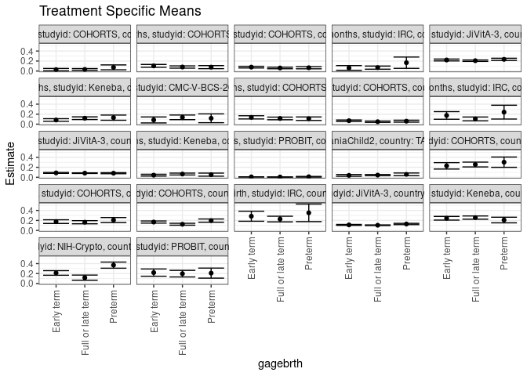

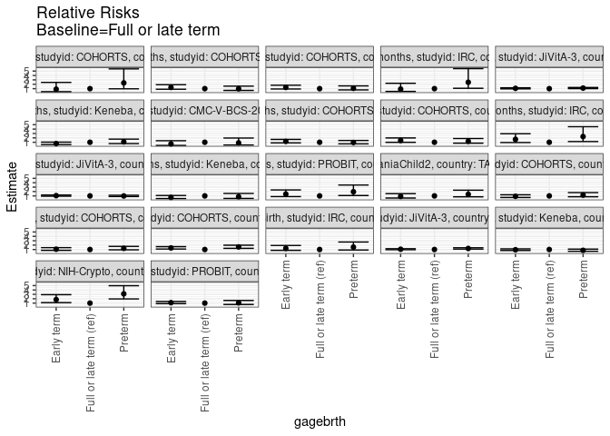

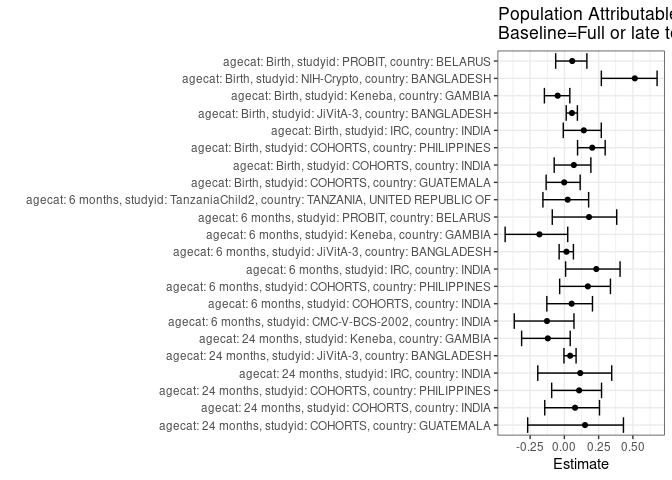

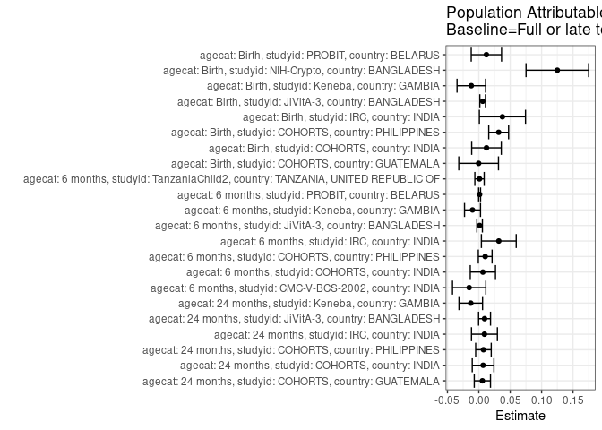

## Results Table

### Parameter: TSM

| agecat | studyid | country | intervention_level | baseline_level | estimate | ci_lower | ci_upper |
| --- | --- | --- | --- | --- | --- | --- | --- |
| Birth | COHORTS | GUATEMALA | Full or late term | NA | 0.2555465 | 0.2076404 | 0.3034527 |
| Birth | COHORTS | GUATEMALA | Preterm | NA | 0.3025661 | 0.1996573 | 0.4054748 |
| Birth | COHORTS | GUATEMALA | Early term | NA | 0.2293008 | 0.1651175 | 0.2934841 |
| Birth | COHORTS | INDIA | Full or late term | NA | 0.1643546 | 0.1333220 | 0.1953871 |
| Birth | COHORTS | INDIA | Preterm | NA | 0.2076540 | 0.1573276 | 0.2579804 |
| Birth | COHORTS | INDIA | Early term | NA | 0.1763761 | 0.1395372 | 0.2132149 |
| Birth | COHORTS | PHILIPPINES | Full or late term | NA | 0.1239041 | 0.1048921 | 0.1429161 |
| Birth | COHORTS | PHILIPPINES | Preterm | NA | 0.1966277 | 0.1644561 | 0.2287993 |
| Birth | COHORTS | PHILIPPINES | Early term | NA | 0.1678544 | 0.1462719 | 0.1894370 |
| Birth | IRC | INDIA | Full or late term | NA | 0.2276156 | 0.1707894 | 0.2844418 |
| Birth | IRC | INDIA | Preterm | NA | 0.3521700 | 0.1761237 | 0.5282164 |
| Birth | IRC | INDIA | Early term | NA | 0.2842303 | 0.1840453 | 0.3844153 |
| Birth | JiVitA-3 | BANGLADESH | Full or late term | NA | 0.1041120 | 0.0972383 | 0.1109856 |
| Birth | JiVitA-3 | BANGLADESH | Preterm | NA | 0.1288058 | 0.1159621 | 0.1416495 |
| Birth | JiVitA-3 | BANGLADESH | Early term | NA | 0.1105631 | 0.1012452 | 0.1198810 |
| Birth | Keneba | GAMBIA | Full or late term | NA | 0.2572922 | 0.2250623 | 0.2895222 |
| Birth | Keneba | GAMBIA | Preterm | NA | 0.2081073 | 0.1520820 | 0.2641326 |
| Birth | Keneba | GAMBIA | Early term | NA | 0.2436539 | 0.2066186 | 0.2806891 |
| Birth | NIH-Crypto | BANGLADESH | Full or late term | NA | 0.1182137 | 0.0667685 | 0.1696589 |
| Birth | NIH-Crypto | BANGLADESH | Preterm | NA | 0.3687226 | 0.3074547 | 0.4299906 |
| Birth | NIH-Crypto | BANGLADESH | Early term | NA | 0.2127338 | 0.1666366 | 0.2588311 |
| Birth | PROBIT | BELARUS | Full or late term | NA | 0.1982684 | 0.1321318 | 0.2644051 |
| Birth | PROBIT | BELARUS | Preterm | NA | 0.2091315 | 0.1085601 | 0.3097029 |
| Birth | PROBIT | BELARUS | Early term | NA | 0.2194175 | 0.1468046 | 0.2920303 |
| 6 months | CMC-V-BCS-2002 | INDIA | Full or late term | NA | 0.1367925 | 0.0904694 | 0.1831155 |
| 6 months | CMC-V-BCS-2002 | INDIA | Preterm | NA | 0.1176471 | 0.0290941 | 0.2062000 |
| 6 months | CMC-V-BCS-2002 | INDIA | Early term | NA | 0.0843373 | 0.0244665 | 0.1442082 |
| 6 months | COHORTS | INDIA | Full or late term | NA | 0.1147481 | 0.0883539 | 0.1411423 |
| 6 months | COHORTS | INDIA | Preterm | NA | 0.1091248 | 0.0740486 | 0.1442010 |
| 6 months | COHORTS | INDIA | Early term | NA | 0.1367184 | 0.1048450 | 0.1685919 |
| 6 months | COHORTS | PHILIPPINES | Full or late term | NA | 0.0490658 | 0.0358183 | 0.0623133 |
| 6 months | COHORTS | PHILIPPINES | Preterm | NA | 0.0596282 | 0.0402007 | 0.0790557 |
| 6 months | COHORTS | PHILIPPINES | Early term | NA | 0.0689156 | 0.0539133 | 0.0839180 |
| 6 months | IRC | INDIA | Full or late term | NA | 0.1047715 | 0.0665961 | 0.1429470 |
| 6 months | IRC | INDIA | Preterm | NA | 0.2406062 | 0.1022222 | 0.3789902 |
| 6 months | IRC | INDIA | Early term | NA | 0.1745830 | 0.0981017 | 0.2510642 |
| 6 months | JiVitA-3 | BANGLADESH | Full or late term | NA | 0.0830792 | 0.0765377 | 0.0896206 |
| 6 months | JiVitA-3 | BANGLADESH | Preterm | NA | 0.0821173 | 0.0714688 | 0.0927657 |
| 6 months | JiVitA-3 | BANGLADESH | Early term | NA | 0.0877064 | 0.0786219 | 0.0967910 |
| 6 months | Keneba | GAMBIA | Full or late term | NA | 0.0653797 | 0.0464444 | 0.0843150 |
| 6 months | Keneba | GAMBIA | Preterm | NA | 0.0531922 | 0.0223269 | 0.0840576 |
| 6 months | Keneba | GAMBIA | Early term | NA | 0.0428811 | 0.0252497 | 0.0605124 |
| 6 months | PROBIT | BELARUS | Full or late term | NA | 0.0056208 | 0.0032178 | 0.0080238 |
| 6 months | PROBIT | BELARUS | Preterm | NA | 0.0108893 | 0.0042617 | 0.0175169 |
| 6 months | PROBIT | BELARUS | Early term | NA | 0.0079167 | 0.0057834 | 0.0100499 |
| 6 months | TanzaniaChild2 | TANZANIA, UNITED REPUBLIC OF | Full or late term | NA | 0.0435998 | 0.0318805 | 0.0553191 |
| 6 months | TanzaniaChild2 | TANZANIA, UNITED REPUBLIC OF | Preterm | NA | 0.0589475 | 0.0318118 | 0.0860832 |
| 6 months | TanzaniaChild2 | TANZANIA, UNITED REPUBLIC OF | Early term | NA | 0.0384225 | 0.0205124 | 0.0563325 |
| 24 months | COHORTS | GUATEMALA | Full or late term | NA | 0.0318302 | 0.0140966 | 0.0495639 |
| 24 months | COHORTS | GUATEMALA | Preterm | NA | 0.0733945 | 0.0244008 | 0.1223881 |
| 24 months | COHORTS | GUATEMALA | Early term | NA | 0.0276243 | 0.0037298 | 0.0515188 |
| 24 months | COHORTS | INDIA | Full or late term | NA | 0.0802681 | 0.0577258 | 0.1028104 |
| 24 months | COHORTS | INDIA | Preterm | NA | 0.0780839 | 0.0474314 | 0.1087363 |
| 24 months | COHORTS | INDIA | Early term | NA | 0.1031795 | 0.0746176 | 0.1317414 |
| 24 months | COHORTS | PHILIPPINES | Full or late term | NA | 0.0610092 | 0.0457064 | 0.0763119 |
| 24 months | COHORTS | PHILIPPINES | Preterm | NA | 0.0659301 | 0.0447732 | 0.0870870 |
| 24 months | COHORTS | PHILIPPINES | Early term | NA | 0.0781353 | 0.0613825 | 0.0948881 |
| 24 months | IRC | INDIA | Full or late term | NA | 0.0680000 | 0.0367537 | 0.0992463 |
| 24 months | IRC | INDIA | Preterm | NA | 0.1666667 | 0.0538133 | 0.2795201 |
| 24 months | IRC | INDIA | Early term | NA | 0.0612245 | 0.0136980 | 0.1087510 |
| 24 months | JiVitA-3 | BANGLADESH | Full or late term | NA | 0.2068257 | 0.1926444 | 0.2210070 |
| 24 months | JiVitA-3 | BANGLADESH | Preterm | NA | 0.2338770 | 0.2122279 | 0.2555261 |
| 24 months | JiVitA-3 | BANGLADESH | Early term | NA | 0.2207873 | 0.2023056 | 0.2392691 |
| 24 months | Keneba | GAMBIA | Full or late term | NA | 0.1191418 | 0.0925099 | 0.1457738 |
| 24 months | Keneba | GAMBIA | Preterm | NA | 0.1300997 | 0.0784377 | 0.1817618 |
| 24 months | Keneba | GAMBIA | Early term | NA | 0.0837426 | 0.0574744 | 0.1100108 |

### Parameter: E(Y)

| agecat | studyid | country | intervention_level | baseline_level | estimate | ci_lower | ci_upper |
| --- | --- | --- | --- | --- | --- | --- | --- |
| Birth | COHORTS | GUATEMALA | NA | NA | 0.2552448 | 0.2194833 | 0.2910062 |
| Birth | COHORTS | INDIA | NA | NA | 0.1765663 | 0.1552399 | 0.1978927 |
| Birth | COHORTS | PHILIPPINES | NA | NA | 0.1555324 | 0.1422803 | 0.1687844 |
| Birth | IRC | INDIA | NA | NA | 0.2652439 | 0.2173954 | 0.3130924 |
| Birth | JiVitA-3 | BANGLADESH | NA | NA | 0.1101917 | 0.1049992 | 0.1153842 |
| Birth | Keneba | GAMBIA | NA | NA | 0.2453092 | 0.2230705 | 0.2675480 |
| Birth | NIH-Crypto | BANGLADESH | NA | NA | 0.2432815 | 0.2116319 | 0.2749310 |
| Birth | PROBIT | BELARUS | NA | NA | 0.2103206 | 0.1450833 | 0.2755580 |
| 6 months | CMC-V-BCS-2002 | INDIA | NA | NA | 0.1213873 | 0.0869266 | 0.1558480 |
| 6 months | COHORTS | INDIA | NA | NA | 0.1211890 | 0.1035235 | 0.1388545 |
| 6 months | COHORTS | PHILIPPINES | NA | NA | 0.0592179 | 0.0502884 | 0.0681474 |
| 6 months | IRC | INDIA | NA | NA | 0.1365979 | 0.1023826 | 0.1708133 |
| 6 months | JiVitA-3 | BANGLADESH | NA | NA | 0.0843705 | 0.0794524 | 0.0892887 |
| 6 months | Keneba | GAMBIA | NA | NA | 0.0553130 | 0.0432217 | 0.0674042 |
| 6 months | PROBIT | BELARUS | NA | NA | 0.0068541 | 0.0051915 | 0.0085167 |
| 6 months | TanzaniaChild2 | TANZANIA, UNITED REPUBLIC OF | NA | NA | 0.0446898 | 0.0354016 | 0.0539780 |
| 24 months | COHORTS | GUATEMALA | NA | NA | 0.0374813 | 0.0230560 | 0.0519065 |
| 24 months | COHORTS | INDIA | NA | NA | 0.0870570 | 0.0717143 | 0.1023997 |
| 24 months | COHORTS | PHILIPPINES | NA | NA | 0.0683690 | 0.0583283 | 0.0784097 |
| 24 months | IRC | INDIA | NA | NA | 0.0769231 | 0.0504429 | 0.1034032 |
| 24 months | JiVitA-3 | BANGLADESH | NA | NA | 0.2159550 | 0.2060514 | 0.2258585 |
| 24 months | Keneba | GAMBIA | NA | NA | 0.1063094 | 0.0885410 | 0.1240778 |

### Parameter: RR

| agecat | studyid | country | intervention_level | baseline_level | estimate | ci_lower | ci_upper |
| --- | --- | --- | --- | --- | --- | --- | --- |
| Birth | COHORTS | GUATEMALA | Full or late term | Full or late term | 1.0000000 | 1.0000000 | 1.000000 |
| Birth | COHORTS | GUATEMALA | Preterm | Full or late term | 1.1839960 | 0.8028945 | 1.745991 |
| Birth | COHORTS | GUATEMALA | Early term | Full or late term | 0.8972958 | 0.6409487 | 1.256169 |
| Birth | COHORTS | INDIA | Full or late term | Full or late term | 1.0000000 | 1.0000000 | 1.000000 |
| Birth | COHORTS | INDIA | Preterm | Full or late term | 1.2634513 | 0.9295352 | 1.717320 |
| Birth | COHORTS | INDIA | Early term | Full or late term | 1.0731437 | 0.8096498 | 1.422390 |
| Birth | COHORTS | PHILIPPINES | Full or late term | Full or late term | 1.0000000 | 1.0000000 | 1.000000 |
| Birth | COHORTS | PHILIPPINES | Preterm | Full or late term | 1.5869344 | 1.2684612 | 1.985367 |
| Birth | COHORTS | PHILIPPINES | Early term | Full or late term | 1.3547124 | 1.1092445 | 1.654500 |
| Birth | IRC | INDIA | Full or late term | Full or late term | 1.0000000 | 1.0000000 | 1.000000 |
| Birth | IRC | INDIA | Preterm | Full or late term | 1.5472140 | 0.8843300 | 2.706989 |
| Birth | IRC | INDIA | Early term | Full or late term | 1.2487295 | 0.8098276 | 1.925503 |
| Birth | JiVitA-3 | BANGLADESH | Full or late term | Full or late term | 1.0000000 | 1.0000000 | 1.000000 |
| Birth | JiVitA-3 | BANGLADESH | Preterm | Full or late term | 1.2371850 | 1.0955462 | 1.397136 |
| Birth | JiVitA-3 | BANGLADESH | Early term | Full or late term | 1.0619635 | 0.9563944 | 1.179186 |
| Birth | Keneba | GAMBIA | Full or late term | Full or late term | 1.0000000 | 1.0000000 | 1.000000 |
| Birth | Keneba | GAMBIA | Preterm | Full or late term | 0.8088365 | 0.6011743 | 1.088231 |
| Birth | Keneba | GAMBIA | Early term | Full or late term | 0.9469928 | 0.7776931 | 1.153148 |
| Birth | NIH-Crypto | BANGLADESH | Full or late term | Full or late term | 1.0000000 | 1.0000000 | 1.000000 |
| Birth | NIH-Crypto | BANGLADESH | Preterm | Full or late term | 3.1191194 | 1.9574424 | 4.970213 |
| Birth | NIH-Crypto | BANGLADESH | Early term | Full or late term | 1.7995703 | 1.1065344 | 2.926663 |
| Birth | PROBIT | BELARUS | Full or late term | Full or late term | 1.0000000 | 1.0000000 | 1.000000 |
| Birth | PROBIT | BELARUS | Preterm | Full or late term | 1.0547896 | 0.6933913 | 1.604550 |
| Birth | PROBIT | BELARUS | Early term | Full or late term | 1.1066686 | 0.8852899 | 1.383406 |
| 6 months | CMC-V-BCS-2002 | INDIA | Full or late term | Full or late term | 1.0000000 | 1.0000000 | 1.000000 |
| 6 months | CMC-V-BCS-2002 | INDIA | Preterm | Full or late term | 0.8600406 | 0.3767610 | 1.963234 |
| 6 months | CMC-V-BCS-2002 | INDIA | Early term | Full or late term | 0.6165351 | 0.2807839 | 1.353765 |
| 6 months | COHORTS | INDIA | Full or late term | Full or late term | 1.0000000 | 1.0000000 | 1.000000 |
| 6 months | COHORTS | INDIA | Preterm | Full or late term | 0.9509947 | 0.6407227 | 1.411517 |
| 6 months | COHORTS | INDIA | Early term | Full or late term | 1.1914660 | 0.8594266 | 1.651789 |
| 6 months | COHORTS | PHILIPPINES | Full or late term | Full or late term | 1.0000000 | 1.0000000 | 1.000000 |
| 6 months | COHORTS | PHILIPPINES | Preterm | Full or late term | 1.2152704 | 0.7962072 | 1.854897 |
| 6 months | COHORTS | PHILIPPINES | Early term | Full or late term | 1.4045564 | 0.9933609 | 1.985964 |
| 6 months | IRC | INDIA | Full or late term | Full or late term | 1.0000000 | 1.0000000 | 1.000000 |
| 6 months | IRC | INDIA | Preterm | Full or late term | 2.2964843 | 1.1614950 | 4.540562 |
| 6 months | IRC | INDIA | Early term | Full or late term | 1.6663205 | 0.9418284 | 2.948121 |
| 6 months | JiVitA-3 | BANGLADESH | Full or late term | Full or late term | 1.0000000 | 1.0000000 | 1.000000 |
| 6 months | JiVitA-3 | BANGLADESH | Preterm | Full or late term | 0.9884217 | 0.8518749 | 1.146855 |
| 6 months | JiVitA-3 | BANGLADESH | Early term | Full or late term | 1.0556970 | 0.9297294 | 1.198732 |
| 6 months | Keneba | GAMBIA | Full or late term | Full or late term | 1.0000000 | 1.0000000 | 1.000000 |
| 6 months | Keneba | GAMBIA | Preterm | Full or late term | 0.8135901 | 0.4253198 | 1.556309 |
| 6 months | Keneba | GAMBIA | Early term | Full or late term | 0.6558779 | 0.3967298 | 1.084304 |
| 6 months | PROBIT | BELARUS | Full or late term | Full or late term | 1.0000000 | 1.0000000 | 1.000000 |
| 6 months | PROBIT | BELARUS | Preterm | Full or late term | 1.9373261 | 1.0788654 | 3.478870 |
| 6 months | PROBIT | BELARUS | Early term | Full or late term | 1.4084630 | 0.8413101 | 2.357951 |
| 6 months | TanzaniaChild2 | TANZANIA, UNITED REPUBLIC OF | Full or late term | Full or late term | 1.0000000 | 1.0000000 | 1.000000 |
| 6 months | TanzaniaChild2 | TANZANIA, UNITED REPUBLIC OF | Preterm | Full or late term | 1.3520130 | 0.7933011 | 2.304219 |
| 6 months | TanzaniaChild2 | TANZANIA, UNITED REPUBLIC OF | Early term | Full or late term | 0.8812539 | 0.5147225 | 1.508791 |
| 24 months | COHORTS | GUATEMALA | Full or late term | Full or late term | 1.0000000 | 1.0000000 | 1.000000 |
| 24 months | COHORTS | GUATEMALA | Preterm | Full or late term | 2.3058104 | 0.9665200 | 5.500933 |
| 24 months | COHORTS | GUATEMALA | Early term | Full or late term | 0.8678637 | 0.3101816 | 2.428214 |
| 24 months | COHORTS | INDIA | Full or late term | Full or late term | 1.0000000 | 1.0000000 | 1.000000 |
| 24 months | COHORTS | INDIA | Preterm | Full or late term | 0.9727878 | 0.6008496 | 1.574963 |
| 24 months | COHORTS | INDIA | Early term | Full or late term | 1.2854357 | 0.8686292 | 1.902244 |
| 24 months | COHORTS | PHILIPPINES | Full or late term | Full or late term | 1.0000000 | 1.0000000 | 1.000000 |
| 24 months | COHORTS | PHILIPPINES | Preterm | Full or late term | 1.0806589 | 0.7194861 | 1.623136 |
| 24 months | COHORTS | PHILIPPINES | Early term | Full or late term | 1.2807136 | 0.9210548 | 1.780814 |
| 24 months | IRC | INDIA | Full or late term | Full or late term | 1.0000000 | 1.0000000 | 1.000000 |
| 24 months | IRC | INDIA | Preterm | Full or late term | 2.4509804 | 1.0813122 | 5.555569 |
| 24 months | IRC | INDIA | Early term | Full or late term | 0.9003601 | 0.3653015 | 2.219121 |
| 24 months | JiVitA-3 | BANGLADESH | Full or late term | Full or late term | 1.0000000 | 1.0000000 | 1.000000 |
| 24 months | JiVitA-3 | BANGLADESH | Preterm | Full or late term | 1.1307928 | 1.0082185 | 1.268269 |
| 24 months | JiVitA-3 | BANGLADESH | Early term | Full or late term | 1.0675044 | 0.9565603 | 1.191316 |
| 24 months | Keneba | GAMBIA | Full or late term | Full or late term | 1.0000000 | 1.0000000 | 1.000000 |
| 24 months | Keneba | GAMBIA | Preterm | Full or late term | 1.0919737 | 0.6935148 | 1.719367 |
| 24 months | Keneba | GAMBIA | Early term | Full or late term | 0.7028815 | 0.4786808 | 1.032091 |

### Parameter: PAR

| agecat | studyid | country | intervention_level | baseline_level | estimate | ci_lower | ci_upper |
| --- | --- | --- | --- | --- | --- | --- | --- |
| Birth | COHORTS | GUATEMALA | Full or late term | NA | -0.0003018 | -0.0319256 | 0.0313221 |
| Birth | COHORTS | INDIA | Full or late term | NA | 0.0122118 | -0.0113739 | 0.0357974 |
| Birth | COHORTS | PHILIPPINES | Full or late term | NA | 0.0316283 | 0.0158089 | 0.0474476 |
| Birth | IRC | INDIA | Full or late term | NA | 0.0376283 | 0.0008470 | 0.0744097 |
| Birth | JiVitA-3 | BANGLADESH | Full or late term | NA | 0.0060798 | 0.0015945 | 0.0105650 |
| Birth | Keneba | GAMBIA | Full or late term | NA | -0.0119830 | -0.0347113 | 0.0107453 |
| Birth | NIH-Crypto | BANGLADESH | Full or late term | NA | 0.1250678 | 0.0752250 | 0.1749105 |
| Birth | PROBIT | BELARUS | Full or late term | NA | 0.0120522 | -0.0121082 | 0.0362126 |
| 6 months | CMC-V-BCS-2002 | INDIA | Full or late term | NA | -0.0154052 | -0.0419343 | 0.0111240 |
| 6 months | COHORTS | INDIA | Full or late term | NA | 0.0064410 | -0.0136360 | 0.0265179 |
| 6 months | COHORTS | PHILIPPINES | Full or late term | NA | 0.0101521 | -0.0008176 | 0.0211219 |
| 6 months | IRC | INDIA | Full or late term | NA | 0.0318264 | 0.0040905 | 0.0595623 |
| 6 months | JiVitA-3 | BANGLADESH | Full or late term | NA | 0.0012913 | -0.0031047 | 0.0056873 |
| 6 months | Keneba | GAMBIA | Full or late term | NA | -0.0100667 | -0.0227930 | 0.0026596 |
| 6 months | PROBIT | BELARUS | Full or late term | NA | 0.0012333 | -0.0002880 | 0.0027547 |
| 6 months | TanzaniaChild2 | TANZANIA, UNITED REPUBLIC OF | Full or late term | NA | 0.0010900 | -0.0063293 | 0.0085093 |
| 24 months | COHORTS | GUATEMALA | Full or late term | NA | 0.0056510 | -0.0072744 | 0.0185765 |
| 24 months | COHORTS | INDIA | Full or late term | NA | 0.0067889 | -0.0104782 | 0.0240559 |
| 24 months | COHORTS | PHILIPPINES | Full or late term | NA | 0.0073599 | -0.0050364 | 0.0197562 |
| 24 months | IRC | INDIA | Full or late term | NA | 0.0089231 | -0.0117124 | 0.0295586 |
| 24 months | JiVitA-3 | BANGLADESH | Full or late term | NA | 0.0091293 | -0.0003737 | 0.0186322 |
| 24 months | Keneba | GAMBIA | Full or late term | NA | -0.0128324 | -0.0316118 | 0.0059470 |

### Parameter: PAF

| agecat | studyid | country | intervention_level | baseline_level | estimate | ci_lower | ci_upper |
| --- | --- | --- | --- | --- | --- | --- | --- |
| Birth | COHORTS | GUATEMALA | Full or late term | NA | -0.0011823 | -0.1330697 | 0.1153537 |
| Birth | COHORTS | INDIA | Full or late term | NA | 0.0691625 | -0.0743177 | 0.1934802 |
| Birth | COHORTS | PHILIPPINES | Full or late term | NA | 0.2033548 | 0.0962200 | 0.2977897 |
| Birth | IRC | INDIA | Full or late term | NA | 0.1418631 | -0.0078833 | 0.2693609 |
| Birth | JiVitA-3 | BANGLADESH | Full or late term | NA | 0.0551743 | 0.0134846 | 0.0951022 |
| Birth | Keneba | GAMBIA | Full or late term | NA | -0.0488484 | -0.1456988 | 0.0398148 |
| Birth | NIH-Crypto | BANGLADESH | Full or late term | NA | 0.5140867 | 0.2698398 | 0.6766303 |
| Birth | PROBIT | BELARUS | Full or late term | NA | 0.0573038 | -0.0634437 | 0.1643412 |
| 6 months | CMC-V-BCS-2002 | INDIA | Full or late term | NA | -0.1269093 | -0.3655987 | 0.0700603 |
| 6 months | COHORTS | INDIA | Full or late term | NA | 0.0531480 | -0.1278696 | 0.2051132 |
| 6 months | COHORTS | PHILIPPINES | Full or late term | NA | 0.1714365 | -0.0343436 | 0.3362771 |
| 6 months | IRC | INDIA | Full or late term | NA | 0.2329933 | 0.0090415 | 0.4063330 |
| 6 months | JiVitA-3 | BANGLADESH | Full or late term | NA | 0.0153055 | -0.0381934 | 0.0660475 |
| 6 months | Keneba | GAMBIA | Full or late term | NA | -0.1819956 | -0.4322367 | 0.0245233 |
| 6 months | PROBIT | BELARUS | Full or late term | NA | 0.1799380 | -0.0882413 | 0.3820289 |
| 6 months | TanzaniaChild2 | TANZANIA, UNITED REPUBLIC OF | Full or late term | NA | 0.0243905 | -0.1565077 | 0.1769931 |
| 24 months | COHORTS | GUATEMALA | Full or late term | NA | 0.1507692 | -0.2677534 | 0.4311253 |
| 24 months | COHORTS | INDIA | Full or late term | NA | 0.0779820 | -0.1430828 | 0.2562942 |
| 24 months | COHORTS | PHILIPPINES | Full or late term | NA | 0.1076491 | -0.0926628 | 0.2712389 |
| 24 months | IRC | INDIA | Full or late term | NA | 0.1160000 | -0.1939710 | 0.3454983 |
| 24 months | JiVitA-3 | BANGLADESH | Full or late term | NA | 0.0422740 | -0.0029386 | 0.0854483 |
| 24 months | Keneba | GAMBIA | Full or late term | NA | -0.1207080 | -0.3119415 | 0.0426506 |